# Quarto 導入手順 (Mac)

R GUI + テキストエディタ + ターミナル。RStudio は使いません

作者

公開

2026年9月27日

上から順に実施してください。使う道具は4つで、互いに独立しています。

| 道具 | 役割 |
| --- | --- |
| R | 計算と作図 |
| テキストエディタ | `.qmd` ファイルを書く |
| ターミナル | コマンドを打つ |
| Quarto | `.qmd` を html / pdf / docx に変換する |

# 1 ターミナルとは

- 画面にコマンドを1行打ち込み、Enter で実行するための窓
- マウスで押すボタンの代わりに、名前を打って命令する
- Mac には最初から「ターミナル」が入っています。追加のインストールは不要です

開き方: `⌘ + スペース` で Spotlight を出し、`ターミナル` と打って Enter。

よく使う4つだけ覚えれば足ります。

| 打つもの | すること |
| --- | --- |
| `cd フォルダ名` | そのフォルダへ移動する |
| `cd ..` | 1つ上のフォルダへ戻る |
| `ls` | いまのフォルダの中身を並べる |
| `exit` | ターミナルを閉じる |

貼り付けは `⌘ + V` です。

# 2 インストレーション

## 2.1 ターミナル

Mac には最初から入っています。追加のインストールは不要です。 履歴の使い方は「設定」の「ターミナル用履歴表示」を見てください。

## 2.2 R

### 2.2.1 バイナリ(実行ファイル)

https://cran.r-project.org/bin/macosx/ を開き、自分の Mac に合う `.pkg` を落とします。

- (アップルメニュー) → 「この Mac について」→「チップ」欄を見る
- `Apple M1` / `M2` / `M3` / `M4` など → **arm64** と書かれた `.pkg`
- `Intel` → **x86_64** と書かれた `.pkg`

落ちてきた `.pkg` を開き、すべて既定のまま進みます。

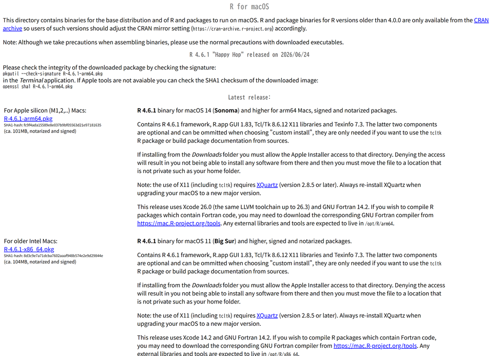

CRAN の macOS 版ページ。チップに合う .pkg を1つ選びます

起動は、アプリケーションフォルダの「**R**」です。`R Console` という窓が出ます。これが R GUI です。

### 2.2.2 ライブラリ

R GUI の `R Console` 窓に、次の1行を貼って Enter。数分かかります。

```r
install.packages(c("quarto", "rmarkdown", "knitr", "ggplot2"))
```

途中でミラーサイトを聞かれたら `Japan` のどれかを選びます。

### 2.2.3 Pandoc

rmarkdown は変換に Pandoc を使います。 入っているか確かめます。

```r
rmarkdown::pandoc_available()
```

`FALSE` なら https://pandoc.org/installing.html から macOS 用の `.pkg` を入れ(Homebrew なら `brew install pandoc`)、R を開き直します。`TRUE` なら次へ。

Homebrew で入れた場合、アプリケーションフォルダから起動した R からは Pandoc が 見つからず、`FALSE` のままになることがあります。そのときは `.pkg` で入れ直すか、 「実行方法」の RMarkdown の項にある1行で Quarto の Pandoc を使ってください。

## 2.3 Quarto

### 2.3.1 実行ファイル

https://quarto.org/docs/download/ を開き、表の **macOS** 行の `.pkg` を落とします。 開いて、すべて既定のまま進みます。

[figure not shown]

Quarto のダウンロードページ。表の macOS 行の .pkg

入ったか確かめます。ターミナルに貼って Enter。

```
quarto check
```

### 2.3.2 Homebrewを使う方法

Homebrew は、ターミナルからアプリを入れる・更新するための道具です。

1. Homebrew を入れる([公式](https://brew.sh/ja/))。ターミナルに貼って Enter。 途中で Mac のパスワードを聞かれます(打っても画面には出ません)。

   ```
   /bin/bash -c "$(curl -fsSL https://raw.githubusercontent.com/Homebrew/install/HEAD/install.sh)"
   ```

2. 終わりに `Next steps:` と表示されたら、その下に字下げして出るコマンド (ふつうは3行)をそのまま貼って Enter。`brew` を使えるようにする設定です
3. Quarto を入れる([Homebrew の Quarto ページ](https://formulae.brew.sh/cask/quarto))

   ```
   brew install --cask quarto
   ```

4. 後で新しい版に上げるときは `brew upgrade --cask quarto`

### 2.3.3 Pandoc

Quarto には Pandoc が同梱されています。Quarto のために別途入れる必要はありません。

## 2.4 テキスト・エディタ

どちらか1つで足ります。両方入れる必要はありません。

表 1: CotEditor と Sublime Text の比較

| くらべる点 | CotEditor | Sublime Text |
| --- | --- | --- |
| 料金 | 無料 | 有料ライセンス。無期限試用できる |
| 画面の言語 | 日本語 (Mac の言語設定に従う) | 英語。Japanize で日本語メニューにできる |
| 入れ方 | App Store / 公式サイト | 公式サイトの .dmg |
| R の色分け | 最初から入っている | 最初から入っている |
| Markdown の色分け | 最初から入っている | 最初から入っている |
| 向いている人 | Mac だけで使う人、設定を増やしたくない人 | Windows / Linux でも同じエディタを使いたい人 |

出典: [CotEditor 公式](https://coteditor.com/)、[Sublime Text 公式](https://www.sublimetext.com/)、 各エディタに同梱の色分け定義 ([CotEditor](https://github.com/coteditor/CotEditor/tree/main/CotEditor/Resources/Syntaxes)、 [Sublime Text](https://github.com/sublimehq/Packages))。

### 2.4.1 CotEditor

https://coteditor.com/ から、または App Store で `CotEditor` を検索して入れます。 画面は日本語です。

[figure not shown]

CotEditor 公式サイト

### 2.4.2 Sublime Text

https://www.sublimetext.com/download の **Mac** 用を落とし、 `.dmg` の中の Sublime Text をアプリケーションフォルダへ入れます。

[figure not shown]

Sublime Text のダウンロードページ。Mac 用を選びます

#### 2.4.2.1 メニューを日本語にする (Japanize)

[Japanize](https://github.com/kik0220/sublimetext_japanize) の手順です。

1. Sublime Text で `⌘ + Shift + P` → `Install Package Control` を実行する
2. もう一度 `⌘ + Shift + P` → `Package Control: Install Package` → `Japanize` を選ぶ
3. `Sublime Text` → `Settings` → `Browse Packages…` で Packages フォルダを開く (場所は `~/Library/Application Support/Sublime Text/Packages/`)
4. `Japanize` フォルダの `*.jp` ファイルを、すべて `Default` フォルダへコピーする (`Default` が無ければ作る)
5. コピーしたファイルの名前から `.jp` を取り、元のファイルと置き換える
6. `Japanize` フォルダの `Main.sublime-menu` を `User` フォルダへコピーする

[figure not shown]

Japanize の配布ページ